# Decoding Intracellular Pathogen of H3N2 at the Single-Cell level using Yeskit

# 4 Integration

Then, we integrate these two `Seurat` object

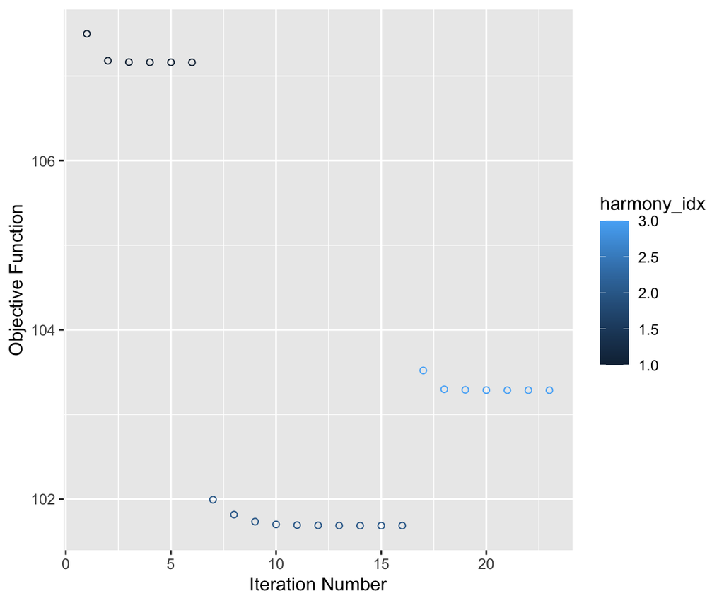

```
## Modularity Optimizer version 1.3.0 by Ludo Waltman and Nees Jan van Eck
##
## Number of nodes: 92
## Number of edges: 3856
##
## Running Louvain algorithm...
## Maximum modularity in 10 random starts: 0.3583
## Number of communities: 2
## Elapsed time: 0 seconds
```

```r
#| fig.cap="Harmony Interation"
Integrated <- scIntegrate(object.list=list(Bystander, Infected),
                          object.names = c("Bystander", "Infected"),
                          batch.rm = "harmony", resolution = 0.7)
```

# 5 Differential analysis

## 5.1 Differential analysis between Infected and Bystander

```r
slot(Integrated, "misc")$Infected_vs_Bystander <- scDGE(object = Integrated,
                         comparison = c("Infected", "Bystander"),
                         group.by = "group", min.cells = 10,
                         logFC = 0.25, clusters = NULL)
```

## 5.2 Differential analysis between H3N2_positive and H3N2_negative

```r
slot(Integrated, "misc")$H3N2 <- scPathogenDGE(object = Integrated,
                         species.by = "H3N2", min.cells = 5)
```

# 6 GO annotation

## 6.1 GO annotation of DGEs between Infected and Bystander

```r
slot(Integrated, "misc")$Infected_vs_Bystander.GO <- scGO(object = Integrated,
                         key = "Infected_vs_Bystander",
                         logFC = 0.25, only.pos = FALSE,
                         reference = "human")
```

```
## [1] "Running cluster 0"
## [1] "Running cluster 1"
```

## 6.2 GO annotation of DGEs between H3N2_positive and H3N2_negative

```r
slot(Integrated, "misc")$H3N2.GO <- scPathogenGO(object = Integrated,
                         key = "H3N2", clusters = NULL, species = "H3N2",
                         logFC = 0.25)
```

# 7 MSigDB scoring

```r
Integrated <- scMsigdbScoring(object = Integrated,
                              category = "H",
                              genesets = "HALLMARK_INFLAMMATORY_RESPONSE"
                              )
```

# 8 Visualization

## 8.1 Visualization of cell clusters by scDimPlot

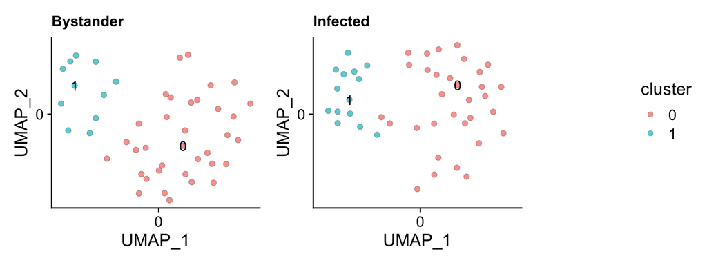

```r
#| fig.cap="Cell DimPlot"
scDimPlot(object = Integrated,
          reduction = "umap",
          cols = NULL,
          split.by = "sample",
          ncol = 2,
          pt.size = 2)
```

## 8.2 Visualization of cell densities by scDensityPlot

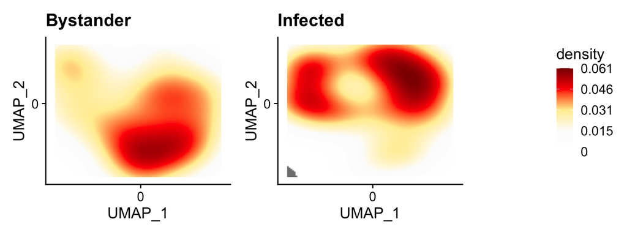

```r
#| fig.cap="Cell Density Plot"
scDensityPlot(object = Integrated,
              reduction = "umap",
              split.by = "sample",
              ncol = 2)
```

## 8.3 Visualization of cell population fractions by scPopulationPlot,

the x axis stands for clusters

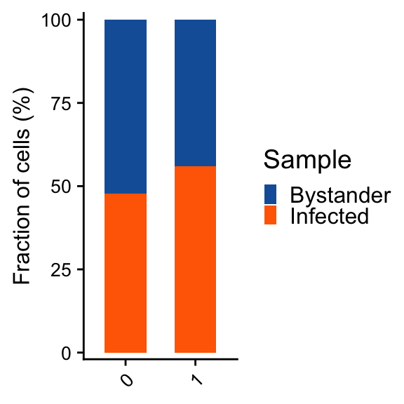

```r
#| fig.cap="Cell Population Plot by cluster"
scPopulationPlot(object = Integrated,
                 by = "cluster",
                 cols = "sc",
                 order = c("Bystander", "Infected"))
```

## 8.4 Visualization of meta data by scVizMeta

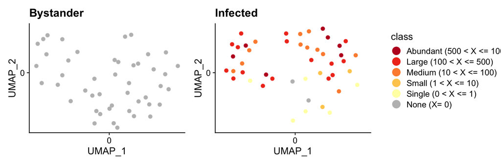

```r
#| fig.cap="H3N2 DimPlot"
scVizMeta(object = Integrated,
          reduction = "umap",
          signature="H3N2",
          title = "H3N2",
          raster = TRUE,
          split.by = "sample",
          pt.size = 2,
          interval = c(
            Abundant = 1000,
            Large = 500,
            Medium = 100,
            Small = 10,
            Single = 1,
            None = 0)
          )
```

## 8.5 Visualization of H3N2-infected cell fractions by scPathogenRatioPlot

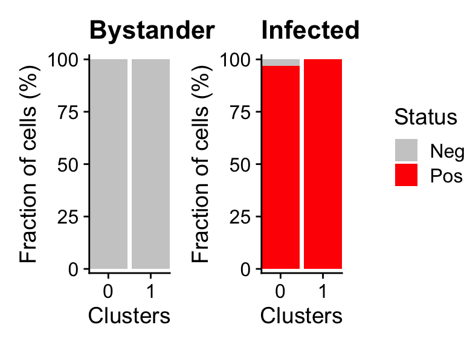

```r
#| fig.cap="H3N2 Ratio Plot"
scPathogenRatioPlot(object = Integrated,
                    species = "H3N2",
                    split.by = "sample",
                    ncol = 2)
```

## 8.6 Visualization of DGEs by scVolcanoPlot

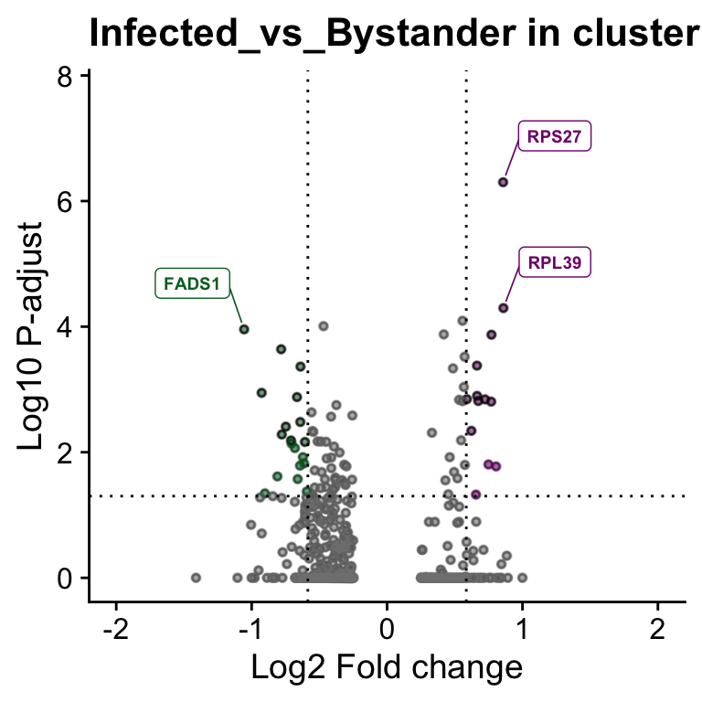

```r
#| fig.cap="Volcano Plot of Infected_vs_Bystander"
scVolcanoPlot(object = Integrated,
              key = "Infected_vs_Bystander",
              cluster = "0",
              top_n = 10)
```

## 8.7 Visualization of enriched GO terms for up-regulated genes by scGOBarPlot

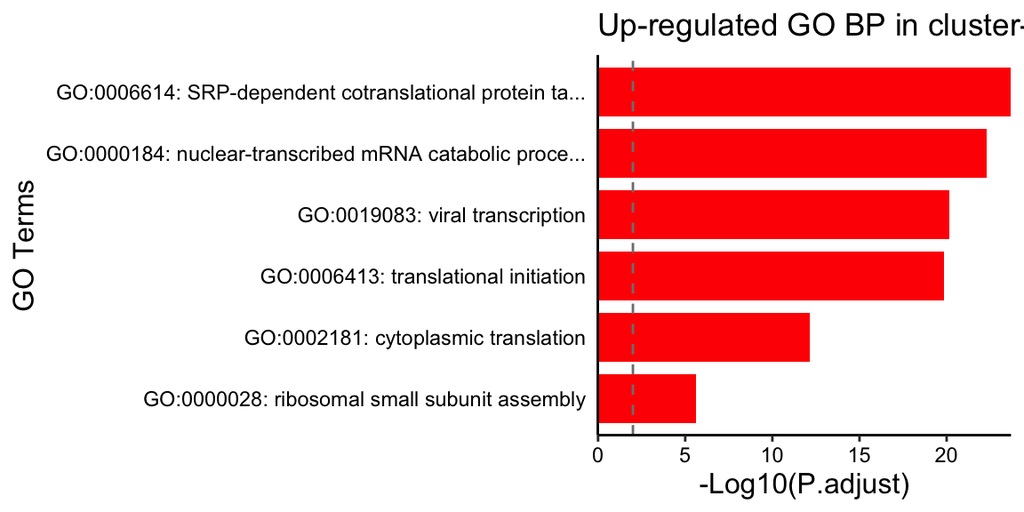

```r
#| fig.cap="Infected_vs_Bystander.GO_up"
scGOBarPlot(object = Integrated,
            key = "Infected_vs_Bystander.GO",
            ont = "BP",
            top_n = 6,
            direction = "up",
            cluster = "0")
```

## 8.8 Visualization of enriched GO terms for down-regulated genes by scGOBarPlot

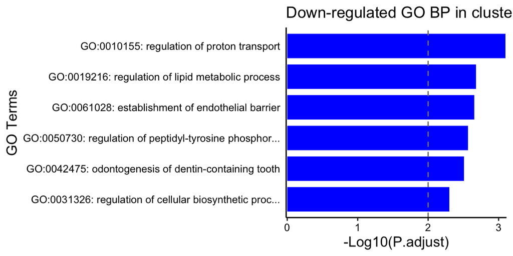

```r
#| fig.cap="Infected_vs_Bystander.GO_down"
scGOBarPlot(object = Integrated,
            key = "Infected_vs_Bystander.GO",
            ont = "BP",
            top_n = 6,
            direction = "down",
            cluster = "0")
```

## 8.9 Visualization of enriched GO terms for up-regulated genes by scGODotPlot

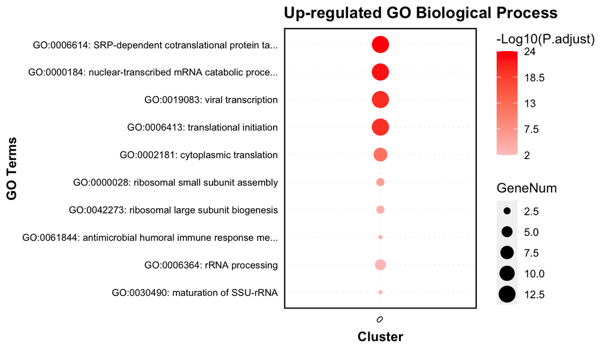

```r
#| fig.cap="Infected_vs_Bystander.GO_up"
scGODotPlot(object = Integrated,
            key = "Infected_vs_Bystander.GO",
            ont = "BP",
            direction = "up",
            top_n = 10,
            font.size = 8)
```

## 8.10 Visualization of enriched GO terms for down-regulated genes by scGODotPlot

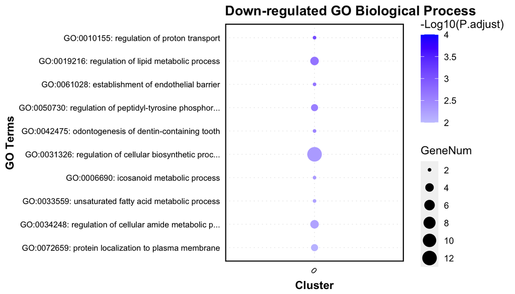

```r
#| fig.cap="Infected_vs_Bystander.GO_down"
scGODotPlot(object = Integrated,
            key = "Infected_vs_Bystander.GO",
            ont = "BP",
            direction = "down",
            top_n = 10,
            clusters = c("0"),
            font.size = 8)
```

## 8.11 BarPlot shows enriched GO terms for up-regulated genes of H3N2pos_vs_H3N2neg

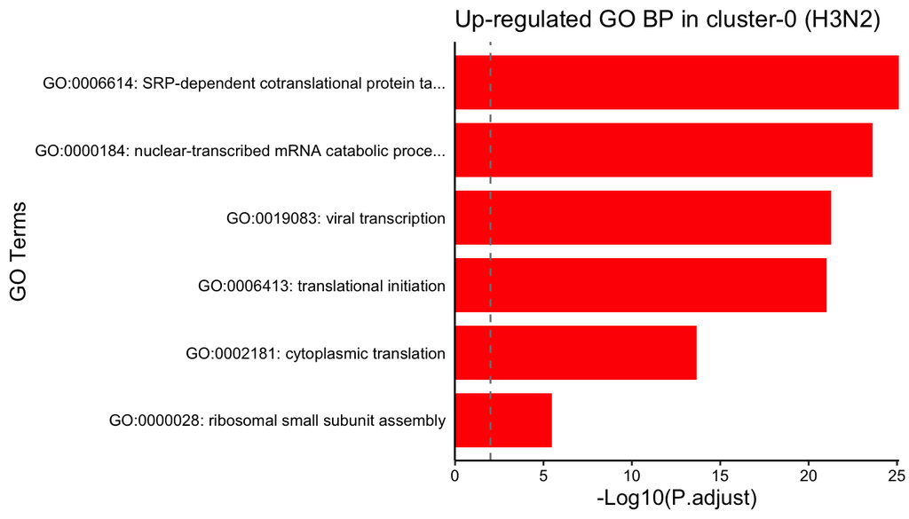

```r
#| fig.cap="H3N2pos_vs_H3N2neg.GO_up"
scGOBarPlot(object = Integrated,
            key = "H3N2.GO",
            cluster = "0",
            extra = "H3N2",
            top_n = 6)
```

## 8.12 DotPlot shows enriched GO terms for up-regulated genes of H3N2pos_vs_H3N2neg

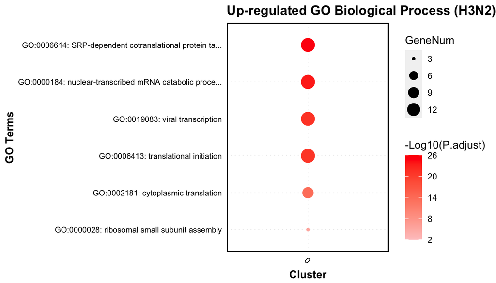

```r
#| fig.cap="H3N2pos_vs_H3N2neg.GO_up"
scGODotPlot(object = Integrated,
            key = "H3N2.GO",
            clusters = "0",
            extra = "H3N2",
            top_n = 6)
```

## 8.13 Visualization of HALLMARK_INFLAMMATORY_RESPONSE pathway

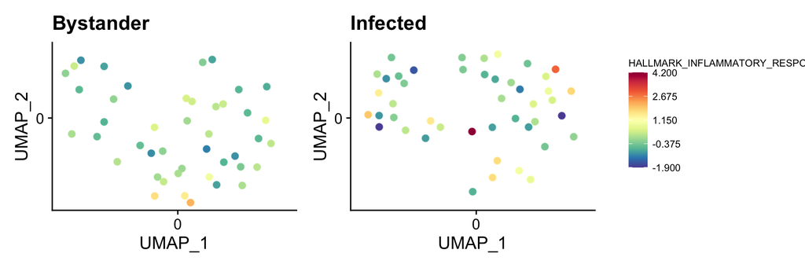

```r
#| fig.cap = "HALLMARK_INFLAMMATORY_RESPONSE"
scScoreDimPlot(object = Integrated,
               signature = "HALLMARK_INFLAMMATORY_RESPONSE",
               split.by="sample",
               ncol = 2,
               pt.size = 2)
```

# 10 References

1. Zheng GXY, Terry JM, Belgrader P et al. Massively parallel digital transcriptional profiling of single cells, Nature Communications 2017;8:14049
2. Stuart T, Butler A, Hoffman P et al. Comprehensive Integration of Single-Cell Data, Cell 2019;177:1888-1902.e1821
3. Korsunsky I, Millard N, Fan J et al. Fast, sensitive and accurate int- egration of single-cell data with Harmony, Nature Methods 2019;16:1289-1296
4. Alexa A, Rahnenführer J. Gene set enrichment analysis with topGO, Bioconductor Improv 2009;27:1-26
5. Liberzon A, Subramanian A, Pinchback R et al. Molecular signatures database (MSigDB) 3.0, Bioinformatics 2011;27:1739-1740
6. Yuan et al. Computational Methods for Single-Cell Data Analysis. Methods in Molecular Biology. 2019;doi:10.1007/978-1-4939-9057-3
7. Borcherding N, Bormann N L, Kraus G. scRepertoire: An R-based toolkit for single-cell immune receptor analysis. F1000Research, 2020, 9
8. Petukhov V. ggrastr: Raster layers for ggplot2. 2018
9. Wickham H. ggplot2. Wiley Interdisciplinary Reviews: Computational Statistics, 2011, 3(2): 180-185
10. Finak G, McDavid A, Yajima M, et al. MAST: a flexible statistical framework for assessing transcriptional changes and characterizing heterogeneity in single-cell RNA sequencing data. Genome biology, 2015, 16(1): 1-13.